# Base Plot in R

Gregoire Michoud

02/01/2018

## Base Plot in R

One of the most powerful functions of R is it’s ability to produce a wide range of graphics to quickly and easily visualise data. Plots can be replicated, modified and even publishable with just a handful of commands.

For this, we are going to use the `airquality` dataset, which measure the daily air quality in New York from May to September 1973, with 6 variables :

- Ozone: Mean ozone in parts per billion from 1300 to 1500 hours at Roosevelt Island
- Solar.R: Solar radiation in Langleys in the frequency band 4000–7700 Angstroms from 0800 to 1200 hours at Central Park
- Wind: Average wind speed in miles per hour at 0700 and 1000 hours at LaGuardia Airport
- Temp: Maximum daily temperature in degrees Fahrenheit at La Guardia Airport.
- Month
- Day

```r
data(airquality)
head(airquality)
```

```
##   Ozone Solar.R Wind Temp Month Day
## 1    41     190  7.4   67     5   1
## 2    36     118  8.0   72     5   2
## 3    12     149 12.6   74     5   3
## 4    18     313 11.5   62     5   4
## 5    NA      NA 14.3   56     5   5
## 6    28      NA 14.9   66     5   6
```

As you can see all variables are numerical, so we will create a factorial variable for plotting purposes later on

```r
airquality$Solar.R_cat<-cut(airquality$Solar.R, c(0,50,100,150,200,250,300,350))
```

### Histograms

A very simple histogram to find the frequency of the temperature

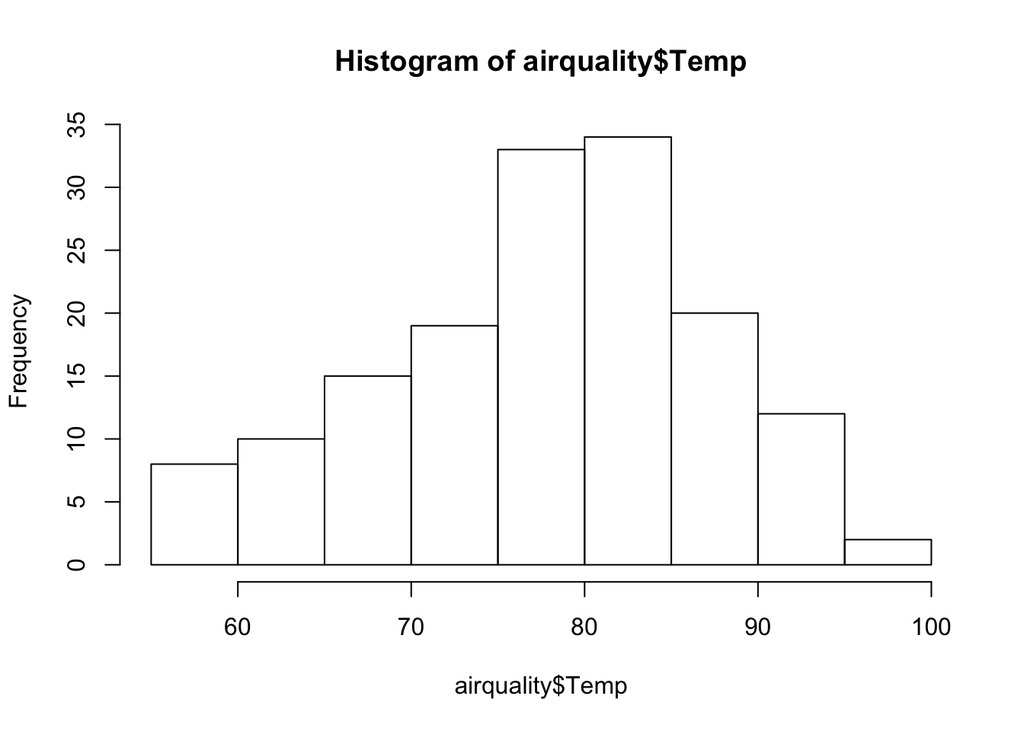

```r
hist(airquality$Temp)
```

A more complex one with the title, x label and we changed the number of cells to 20

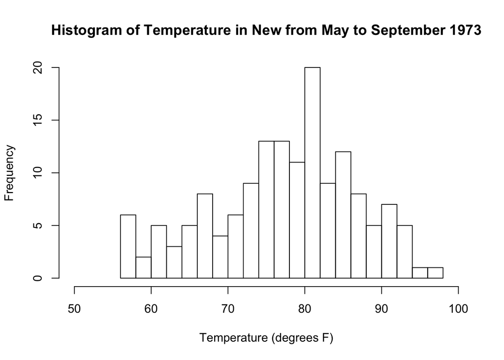

```r
hist(airquality$Temp, breaks = 20, xlab = "Temperature (degrees F)",
     main = "Histogram of Temperature in New from May to September 1973",
     ylim = c(0,20),
     xlim = c(50,100)
)
```

### Scatterplot

A simple scatter plot to compare the ozone concentration and the wind

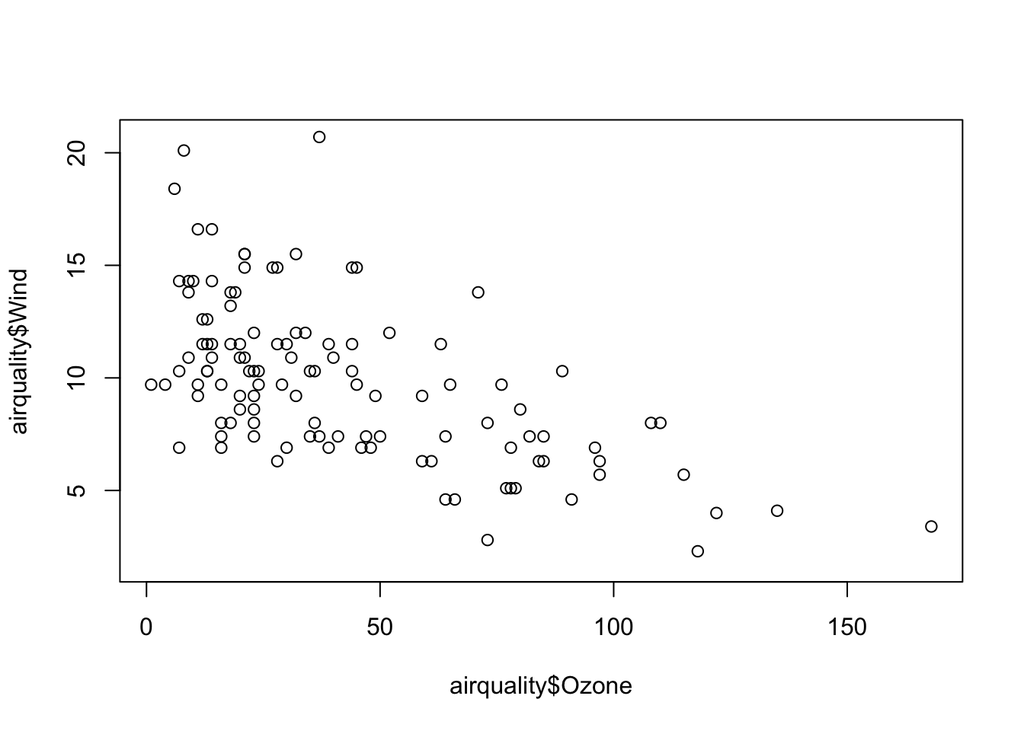

```r
plot(x = airquality$Ozone, y = airquality$Wind)
```

It seems to be negatively correlated, does the solar radiation play a role ?

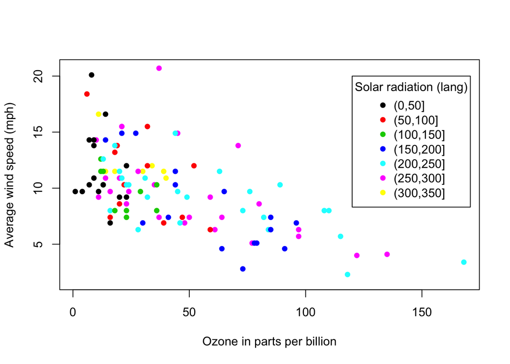

```r
plot(x = airquality$Ozone,
     y = airquality$Wind,
     col = airquality$Solar.R_cat,
     pch = 16,
     xlab = "Ozone in parts per billion",
     ylab = "Average wind speed (mph)")
legend(title = "Solar radiation (lang)", x = 120, y = 20, legend = levels(airquality$Solar.R_cat), col = c(1:7), pch = 16)
```

### Boxplot

Another type of plot

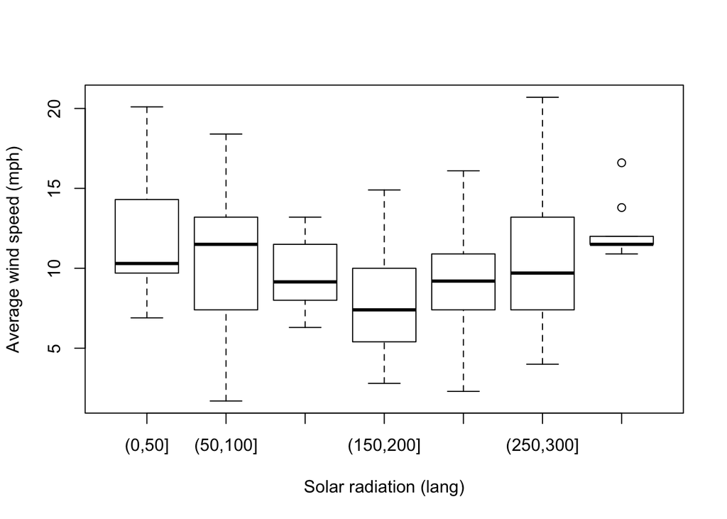

```r
boxplot(airquality$Wind ~ airquality$Solar.R_cat,
        ylab = "Average wind speed (mph)",
        xlab = "Solar radiation (lang)")
```